# Assembling figures, tables and SI for summary-likelihood ms

F. Rousset

2026/03/25

This script has been used to generate the Figures and Tables for the manuscript, from the saved raw simulation results. The latter results were produced with various versions of the `Infusion` package, with minimal version 2.1.186.2 (implementing the ultimately retained values of control parameters of the iterative workflow) for the fits, and minimal version 2.1.196 (implementing a fix for maximization issues of the likelihood surfaces in the bootstrap procedures) for the post-fit analyses. These features are available in version 2.2.0 on CRAN.

# Setup and definitions

```r
# Utilities to make sure necessary files are copied in the published code:
save4MS <- function(file, SIdir="./") {
  copyforMS <- paste0(SIdir,file)
  if ( ! file.exists(copyforMS)) {
    copydir <- dirname(copyforMS)
    if ( ! dir.exists(copydir)) dir.create(copydir, recursive = TRUE)
    file.copy(file, copyforMS)
  }
}

load4MS <- function(file, SIdir="./", ...) {
  save4MS(file=file, SIdir=SIdir)
  load(file, ..., envir=knitr::knit_global())
}

read4MS <- function(file, SIdir="./") {
  save4MS(file=file, SIdir=SIdir)
  read.table(file,dec='.',sep=';')
}
```

```r
library("ggplot2")
library("latex2exp")
par2ltx_backup <- function(v) {
  gsub("V([0-9]*)","$u_{\\1}$", v) # note replacement of V by u
}
par2ltx <- function(v) switch(v,
         "logTh1"=r"[$\log(N_1\bar{\mu})$]",
         "logTh2"=r"[$\log(N_2\bar{\mu})$]",
         "logTh3"=r"[$\log(N_3\bar{\mu})$]",
         "logTh4"=r"[$\log(N_4\bar{\mu})$]",
         "logMu"=r"[$\log(\bar{\mu})$]",
         "MEANP"=r"[$\bar{p}$]",
         "log.N1."=r"[$\log(N_1)$]",
         "log.N2."=r"[$\log(N_2)$]",
         "log.N3."=r"[$\log(N_3)$]",
         "log.N4."=r"[$\log(N_4)$]",
         "N1"=r"[$N_1$]",
         "N2"=r"[$N_2$]",
         "N3"=r"[$N_3$]",
         "N4"=r"[$N_4$]",
         "N34"=r"[$N_{34}$]",
         "t1"=r"[$t_1$]",
         "T1"=r"[$t_1$]",
         "d3"=r"[$d_3$]",
         "d4"=r"[$d_4$]",
         "d34"=r"[$d_{34}$]",
         "ar"=r"[$r_{\textrm{a}}$]",
         "ra"=r"[$r_{\textrm{a}}$]",
         "log.t12."=r"[$\log(t_{12})$]",
         "log1p.t23."=r"[$\log(1+t_{23})$]",
         "Nbn3"=r"[$N_{\textrm{bn3}}$]",
         "Nbn4"=r"[$N_{\textrm{bn4}}$]",
         "Nbn34"=r"[$N_{\textrm{bn34}}$]",
         "log1p.t34."=r"[$\log(1+t_{34})$]",
         "log.Na."=r"[$\log(N_{\textrm{a}})$]",
         "d3_Nbn3"=r"[$d_3/N_{\textrm{bn3}}$]",
         "d4_Nbn4"=r"[$d_4/N_{\textrm{bn4}}$]",
         "d34_Nbn34"=r"[$d_{34}/N_{\textrm{bn34}}$]",
         "log.Nbn3."=r"[$\log(N_{\textrm{bn3}})$]",
         "log.Nbn4."=r"[$\log(N_{\textrm{bn4}})$]",
         "log.Nbn34."=r"[$\log(N_{\textrm{bn34}})$]",
         par2ltx_backup(v))
# usage: latex2exp::TeX(par2ltx(v))

prettyround <- function(x,extradigits=0) {
    ## extradigits=0 => 99(99)99->99(99)99; 999.9->999.9; 9.999->9.999; 0.xxx -> 3 chifres signif
    for(i in seq_len(length(x))) {
      xi <- x[i]
      if (is.na(xi)) {
        x[i] <- NA
      } else {
        if (xi<1) {n<-3} else if (xi>1000) {n <- ceiling(log(xi,10))} else {n <- 4}
        n <- n+extradigits
        x[i] <- round(xi,n)
      }
    }
    x
}

xyfn  <- function(idx,xsep,ysep, steps=7L) {
  xshift <- (idx-1) %/% (steps)
  idx  <- (idx-1) %% steps
  c( x = 0.9+(idx)*(xsep-ysep)+xshift*steps*xsep + xsep/5, # final correction xsep/5 is ad-hoc
     y = 0.9-(idx)*ysep)
}

ord_names <- c('bias.MSLE', 'bias.postEv', 'bias.postMed',
               'RMSE.MSLE', 'RMSE.postEv', 'RMSE.postMed',
               'cvrg.basicP', 'cvrg.rawbootP', 'cvrg.perc', 'cvrg.mslCI',
               'cvrg.bartlettP', 'cvrg.postCI', 'cvrg.HPDint_d')
if (bootCI=="percCI") {
  inmain <- setdiff(ord_names, c("cvrg.rstarP","cvrg.pstarBoot","cvrg.mslCI",
                                 "cvrg.mslCI", #"cvrg.HPDint_d",
                                 "cvrg.bartlettP"))
  inms <- setdiff(ord_names,c("cvrg.rstarP","cvrg.pstarBoot","cvrg.mslCI",                                             "cvrg.bartlettP"))
} else { # show BartlettP instead.
  inmain <- setdiff(ord_names, c("cvrg.rstarP","cvrg.pstarBoot","cvrg.mslCI",
                                 "cvrg.mslCI", # "cvrg.HPDint_d",
                                 "cvrg.perc"))
  inms <- setdiff(ord_names,c("cvrg.rstarP","cvrg.pstarBoot","cvrg.mslCI",                                             "cvrg.perc"))
}
bias_pos <- which(ord_names %in% c("bias.MSLE", "bias.postEv", "bias.postMed"))
RMSE_pos <- which(ord_names %in% c("RMSE.MSLE", "RMSE.postEv", "RMSE.postMed"))

vec2tex  <- function(locv, retained, bias_pos, RMSE_pos,
                     cvrg_pos=setdiff(seq_along(ord_names),c(bias_pos,RMSE_pos)),
                     loc_ord_names) {
  locv <- locv[retained]
  if (missing(loc_ord_names)) {
    locv <- locv[intersect(ord_names,names(locv))] ## using global 'ord_names' variable
  } else locv <- locv[intersect(loc_ord_names,names(locv))]
  minBias <- bias_pos[which.min(abs(locv[bias_pos]))]
  minRMSE <- RMSE_pos[which.min(abs(locv[RMSE_pos]))]
  oldopt <- options(scipen=666)
  char_locv <- paste0(round(locv,digits = 5),"00000")
  options(oldopt)
  char_locv[char_locv=="100000"] <- "1.00000"
  isnegvals <-  locv < 0
  for (it in seq_along(char_locv)) {
   char_locv[it]  <- substring(char_locv[it],1L,
                               2L+max(3L, -floor(log(abs(locv[it]),10))) +isnegvals[it])
  }
  char_locv[minBias] <- paste0("\\textbf{",char_locv[minBias],"}")
  char_locv[minRMSE] <- paste0("\\textbf{",char_locv[minRMSE],"}")
  cvrg_pos <- intersect(grep("cvrg",names(locv)),cvrg_pos)
  if (length(cvrg_pos)>1L) {
    absd <- abs(locv[cvrg_pos]-0.95)
    bestcvrg <- cvrg_pos[which(absd<min(absd)+1e-4)]
    char_locv[bestcvrg] <- paste0("\\textbf{",char_locv[bestcvrg],"}")
  }
  paste(paste(char_locv,collapse=" & "),"\\\\ ")
}

  plot_ecdfs <- function(ecdfs_df, parm, which.p="basicLRT", ...) {
    LRTs <- df_extract(ecdfs_df, c("SLRTs",parm, which.p))[,"p_value"]
    plot(ecdf(LRTs), ...)
  }

calc_ggplot <- function(scaDGparlist, ecdfs_df, modelpath_nickname,
                        which.p, xsep, filename, scale_col=NULL,
                        steps=if (npar<9L) {npar} else {7L},
                        parms=names(scaDGparlist),
                        texlabels=lapply(parms, function(v) TeX(par2ltx(v)))
                        ) {
  npar <- length(parms)
  ecdfs_pv  <- sapply(parms, function(parm) {df_extract(ecdfs_df, c("SLRTs",parm, which.p))[,"p_value"]})
  nr <- nrow(ecdfs_pv)
  ysep <- 1/steps
  tib  <- as.data.frame(ecdfs_pv+(as.numeric(gl(npar,nr))-1)*xsep)
  tib   <- tidyr::pivot_longer(tib,seq(npar),names_to="parameter")
  tib$parameter <- factor(tib$parameter, levels=parms)

  dev.new(width=10, height=2.5)

  myplot <- ggplot(tib, aes(value, col=parameter))
  if ( ! is.null(scale_col)) myplot <- myplot + scale_color_manual(values=scale_col)
  for (it in seq(npar)) {
    xy   <- xyfn(it,xsep=xsep,ysep=ysep, steps=steps)
    myplot <- myplot +
      geom_abline(slope=1,intercept=-(it-1)*xsep, col="grey") +
      annotate("text", x = xy["x"], y = xy["y"],
      #https://stackoverflow.com/questions/63095027/why-does-ggplot-annotate-throw-this-warning-in-is-nax-is-na-applied-to-no               l
               label = attr(texlabels[[it]],"plotmath"), parse=TRUE,
               size=4)
  }

  myplot <- myplot + stat_ecdf(geom="step") + theme_void() +
    coord_fixed() +
    labs(y="CDF of p-values\n") +
    theme(
      axis.title.y =  element_text(angle = 90),
      axis.ticks.y = element_line(),
      axis.line.y = element_line(),
      axis.text.y = element_text(),
      legend.position="none"
    ) +
    scale_y_continuous(breaks=seq(0,1,0.25)) +
    scale_x_continuous(expand=expansion(mult=c(0.01,0.05)))

  ggsave(filename=filename)
  return(myplot)
}

plot. <- FALSE
```

# Ladybird invasion scenario (8 parameters)

## First set of parameters

### Base simulations

```r
modelpath_nickname <- "D_axy_8pars"
load4MS("diy2inf_simuls/Harmonia/D_axy_8pars/saves4Rmd.rda", verbose=TRUE)
```

```
## Loading objects:
##   LOWER
##   UPPER
##   scaDGparlist
```

```r
load4MS("diy2inf_simuls/Harmonia/D_axy_8pars/summaries_list.1_400.v2.1.203.rda") # *all* new
lnames <- names(summaries_list)
(full_df_name <- paste0("df_",lnames[1],"_",tail(lnames,1)))
```

```
## [1] "df_1_400"
```

```r
assign(full_df_name, do.call(rbind, summaries_list))
ecdfs_df <- get(full_df_name)
perf_summs <- cp_perf_summs <- ad_hoc_fn(ecdfs_df, DGparlist = scaDGparlist, plot.=plot.)
```

#### Table

```r
# paste0("c('",paste0(perf_names, collapse="', '"),"')")
{
  texcode <- lapply(perf_summs, vec2tex, retained=inmain,
                    bias_pos=bias_pos, RMSE_pos=RMSE_pos)
  texcode <- unlist(texcode)
  partexcode <- sapply(names(texcode), par2ltx )
  texcode <- paste(partexcode,"&", texcode)
  writeLines(texcode, con=paste0(MSdir,"table", modelpath_nickname,".ltx"))
}
```

#### Figure ECDFs

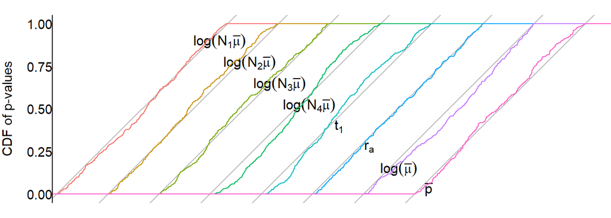

```r
myplot <- calc_ggplot(scaDGparlist, ecdfs_df, modelpath_nickname,
            which.p="basicLRT", xsep=0.3,
            filename=paste0(MSdir,"ecdfs_",modelpath_nickname,".pdf"))
print(myplot)
```

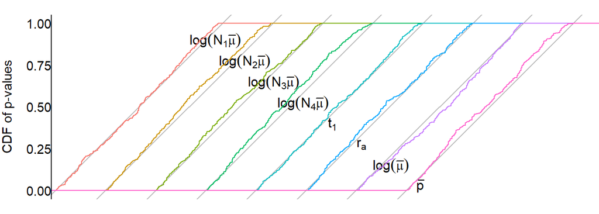

```r
myplot <- calc_ggplot(scaDGparlist, ecdfs_df, modelpath_nickname,
            which.p="rawBootLRT", xsep=0.3,
            filename=paste0(MSdir,"ecdfs_",modelpath_nickname,".rawboot.pdf"))
print(myplot)
```

### Compare inferences of $\log(N_4\bar{\mu})$

```r
modelpath_nickname <- "D_axy_8pars_logTh4"
load4MS("diy2inf_simuls/Harmonia/D_axy_8pars_logTh4/saves4Rmd.rda", verbose=TRUE)
```

```
## Loading objects:
##   LOWER
##   UPPER
##   scaDGparlist
```

```r
load4MS("diy2inf_simuls/Harmonia/D_axy_8pars_logTh4/S_obs_table.rda", verbose=TRUE) # for par.grid
```

```
## Loading objects:
##   S_obs_table
##   S_obs_table_info
```

```r
load4MS("diy2inf_simuls/Harmonia/D_axy_8pars_logTh4/summaries_list.1_200.v2.1.203.rda")
lnames <- names(summaries_list)
(full_df_name <- paste0("df_",lnames[1],"_",tail(lnames,1)))
```

```
## [1] "df_1_200"
```

```r
assign(full_df_name, do.call(rbind, summaries_list))
ecdfs_df <- get(full_df_name)
par.grid <- S_obs_table_info$par.grid
colnames(par.grid) <- names(LOWER)
perf_summs <- ad_hoc_fn(ecdfs_df, DGparlist = scaDGparlist,
                         par.grid=par.grid, plot.=plot.)
```

#### Table

```r
{
  texcode <- lapply(perf_summs, vec2tex, retained=inms,
                    bias_pos=bias_pos, RMSE_pos=RMSE_pos)
  texcode <- unlist(texcode)
  partexcode <- sapply(names(texcode), par2ltx )
  texcode <- paste(partexcode,"&", texcode)
  writeLines(texcode, con=paste0(MSdir,"table", modelpath_nickname,".SI.ltx"))
}
```

#### boxplot

```r
load4MS("diy2inf_simuls/Harmonia/D_axy_8pars_logTh4/S_obs_table.rda", verbose=TRUE) # for S_obs_table_info
```

```
## Loading objects:
##   S_obs_table
##   S_obs_table_info
```

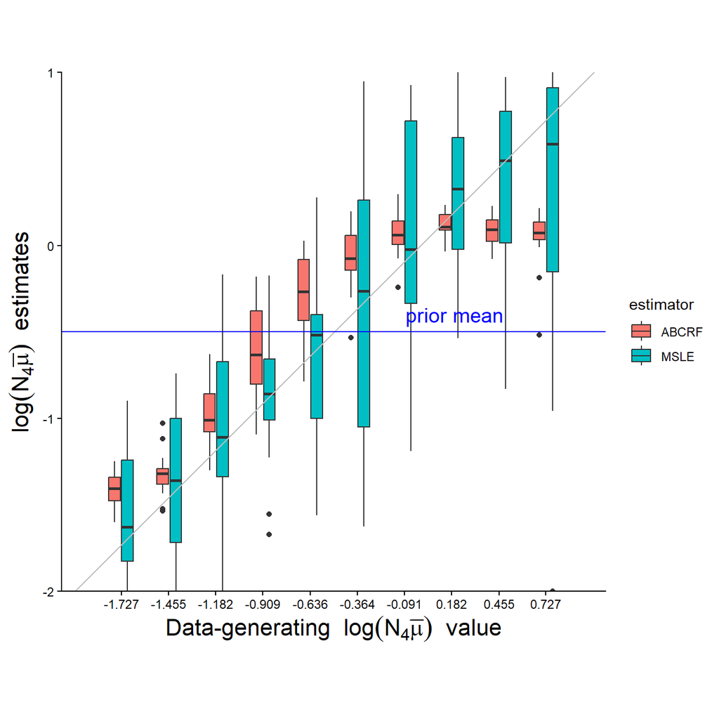

```r
  parm <- "logTh4"
  parmpm <- attr(TeX(par2ltx(parm)),"latex")
  xy_lims <- c(LOWER[parm],UPPER[parm])

  tib <- data.frame(ABCRF=df_extract(ecdfs_df,c("abcrf","logTh4","expectation"))[,1],
                    MSLE=df_extract(ecdfs_df,c("MSL","MSLE","logTh4")))
  tib <- tidyr::pivot_longer(tib,seq(2),names_to="estimator")
  tib$estimator <- factor(tib$estimator)
  unique_x <- unique(S_obs_table_info$par.grid[,parm])
  tib$DGP <- signif(unique_x,3)[gl(10,40)]

  udf <- data.frame(ux=unique_x,uy=unique_x)

  xyplot <- ggplot(tib, aes(x=DGP, # continuous here
                            y=value,
                            group=interaction(DGP,estimator),
                            fill=estimator)
                  ) + geom_boxplot(width=0.15) + theme_classic() +
    coord_fixed() + # to control the proportions of the rendered plot
    labs(x=TeX(paste("Data-generating ",parmpm," value")) ,
         y=TeX(paste(parmpm," estimates"))) +
    theme(
      axis.title.y =  element_text(angle = 90,size=16),
      axis.title.x =  element_text(, size=16),
      axis.ticks.y = element_line(),
      axis.line.y = element_line(),
      axis.text.y = element_text()
    ) +
    scale_y_continuous(limits=c(-2,1), expand=expansion(add=c(0,0)) )  +
    scale_x_continuous(breaks=prettyround(unique_x,), expand=expansion(add=c(3/11,3/11))) +
    geom_abline(slope=1,intercept = 0,col="grey") +
    geom_hline(yintercept=-0.5, col="blue") +
    annotate("text", x = 0.2, y = -0.4, label = "prior mean", size=5, col="blue")

  print(xyplot)
```

```r
  ggsave(filename=paste0(MSdir,"boxp_",modelpath_nickname,".pdf"))
```

### Inference by SNLE using `sbi` python package

The following chunk of code makes sure that all files is included:

```r
save4MS("diy2inf_simuls/Harmonia/D_axy_8pars/SNLE/summarize_snle.R")
```

```
## [1] FALSE
```

```r
filenames <- c("data_HA_INFUSION.txt", "diyabc-RF-linux-v1.1.36-o", "headerRF.txt",
"RNG_state_0000.bin", "S_obs_table.txt", "snle_D_axy_8pars.py", "statobsRF.txt" )
for (nam in filenames) save4MS(paste0("diy2inf_simuls/Harmonia/D_axy_8pars/SNLE/allfilesforeachjob/", nam))
```

```r
modelpath_nickname <- "D_axy_8pars"
load4MS("diy2inf_simuls/Harmonia/D_axy_8pars/saves4Rmd.rda", verbose=TRUE)
```

```
## Loading objects:
##   LOWER
##   UPPER
##   scaDGparlist
```

```r
parms <- names(scaDGP <- unlist(scaDGparlist))
load4MS("diy2inf_simuls/Harmonia/D_axy_8pars/SNLE/SNLE_summaries.rda", verbose=TRUE) # postm, q1s,s2s
```

```
## Loading objects:
##   postm
##   q1s
##   q2s
```

```r
summs <- vector("list", 8L)
names(summs) <- parms
for (parm in parms) {
  m <- (postm[,parm] - scaDGP[parm])/(UPPER[parm] - LOWER[parm])
  cover <- (q1s[,parm]< scaDGP[parm] & q2s[,parm] > scaDGP[parm] )
  summs[[parm]] <- c(cp_perf_summs[[parm]][c("bias.MSLE","RMSE.MSLE","cvrg.mslCI","cvrg.rawbootP","cvrg.bartlettP")],
                     c(bias.SNLE=mean(m),
                          RMSE.SNLE=sqrt(mean(m^2)),
                          cvrg.SNLE=sum(cover)/length(cover))
  )
}

texcode <- lapply(
  summs, vec2tex,
  retained=names(summs[[1]]),
  bias_pos=c(1,6), RMSE_pos=c(2,7), # cvrg_pos=c(3,6),
  loc_ord_names=names(summs[[1]]))
texcode <- unlist(texcode)
partexcode <- sapply(names(texcode), par2ltx )
texcode <- paste(partexcode,"&", texcode)
writeLines(texcode, con=paste0(MSdir,"table", modelpath_nickname,"SNLE.ltx"))
```

## Second set of parameters

### Base simulations

```r
modelpath_nickname <- "A_2023_10_8pars"
load4MS("diy2inf_simuls/Harmonia/A_2023_10_8pars/saves4Rmd.rda", verbose=TRUE)
```

```
## Loading objects:
##   LOWER
##   UPPER
##   scaDGparlist
```

```r
load4MS("diy2inf_simuls/Harmonia/A_2023_10_8pars/summaries_list.1_200.v2.1.203.rda")
lnames <- names(summaries_list)
(full_df_name <- paste0("df_",lnames[1],"_",tail(lnames,1)))
```

```
## [1] "df_1_200"
```

```r
assign(full_df_name, do.call(rbind, summaries_list))
ecdfs_df <- get(full_df_name)
perf_summs <- ad_hoc_fn(ecdfs_df, DGparlist = scaDGparlist, plot.=plot.)
```

#### Table

```r
{
  texcode <- lapply(perf_summs, vec2tex, retained=inms,
                    bias_pos=bias_pos, RMSE_pos=RMSE_pos)
  texcode <- unlist(texcode)
  partexcode <- sapply(names(texcode), par2ltx )
  texcode <- paste(partexcode,"&", texcode)
  writeLines(texcode, con=paste0(MSdir,"table", modelpath_nickname,".SI.ltx"))
}
```

#### Figure ECDFs

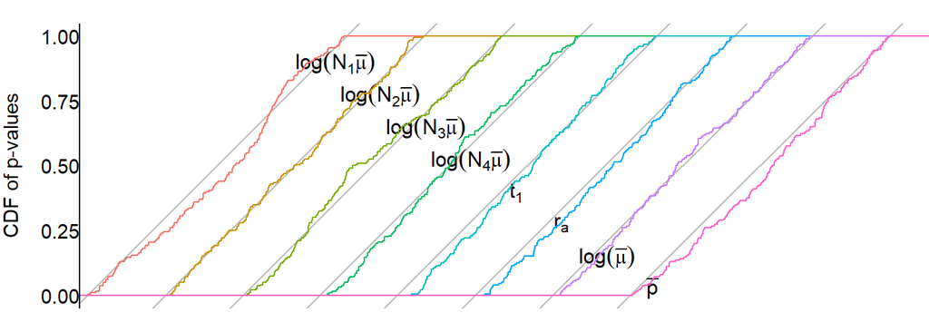

```r
myplot <- calc_ggplot(scaDGparlist, ecdfs_df, modelpath_nickname,
            which.p="basicLRT", xsep=0.3,
            filename=paste0(MSdir,"ecdfs_",modelpath_nickname,".pdf"))
print(myplot)
```

### Alternative sampling

```r
modelpath_nickname <- "A_2023_10_8pars"
load4MS("diy2inf_simuls/Harmonia/A_2023_10_8pars/saves4Rmd.rda", verbose=TRUE)
```

```
## Loading objects:
##   LOWER
##   UPPER
##   scaDGparlist
```

```r
load4MS("diy2inf_simuls/Harmonia/A_2023_10_8pars/summaries_list.altsampling.1_200.v2.1.203.rda")
lnames <- names(summaries_list)
(full_df_name <- paste0("df_",lnames[1],"_",tail(lnames,1)))
```

```
## [1] "df_1_200"
```

```r
assign(full_df_name, do.call(rbind, summaries_list))
ecdfs_df <- get(full_df_name)
perf_summs <- ad_hoc_fn(ecdfs_df, DGparlist = scaDGparlist, plot.=plot.)
```

#### Table

```r
{
  texcode <- lapply(perf_summs, vec2tex, retained=inms,
                    bias_pos=bias_pos, RMSE_pos=RMSE_pos)
  texcode <- unlist(texcode)
  partexcode <- sapply(names(texcode), par2ltx )
  texcode <- paste(partexcode,"&", texcode)
  writeLines(texcode, con=paste0(MSdir,"table", modelpath_nickname,".altsampling.SI.ltx"))
}
```

## Third set of parameter values

### Base simulations

```r
modelpath_nickname <- "C_axy_8pars"
load4MS("diy2inf_simuls/Harmonia/C_axy_8pars/saves4Rmd.rda", verbose=TRUE)
```

```
## Loading objects:
##   LOWER
##   UPPER
##   scaDGparlist
```

```r
load4MS("diy2inf_simuls/Harmonia/C_axy_8pars/summaries_list.1_200.v2.1.203.rda")
lnames <- names(summaries_list)
(full_df_name <- paste0("df_",lnames[1],"_",tail(lnames,1)))
```

```
## [1] "df_1_200"
```

```r
assign(full_df_name, do.call(rbind, summaries_list))
ecdfs_df <- get(full_df_name)
perf_summs <- ad_hoc_fn(ecdfs_df, DGparlist = scaDGparlist, plot.=plot.)
```

#### Table

```r
{
  texcode <- lapply(perf_summs, vec2tex, retained=inms,
                    bias_pos=bias_pos, RMSE_pos=RMSE_pos)
  texcode <- unlist(texcode)
  partexcode <- sapply(names(texcode), par2ltx )
  texcode <- paste(partexcode,"&", texcode)
  writeLines(texcode, con=paste0(MSdir,"table", modelpath_nickname,".SI.ltx"))
}
```

### Compare inferences of $\log(N_4\bar{\mu})$

```r
modelpath_nickname <- "C_axy_8pars_logTh4"
load4MS("diy2inf_simuls/Harmonia/C_axy_8pars_logTh4/saves4Rmd.rda", verbose=TRUE)
```

```
## Loading objects:
##   LOWER
##   UPPER
##   scaDGparlist
```

```r
load4MS("diy2inf_simuls/Harmonia/C_axy_8pars_logTh4/S_obs_table.rda", verbose=TRUE) # for par.grid
```

```
## Loading objects:
##   S_obs_table
##   S_obs_table_info
```

```r
load4MS("diy2inf_simuls/Harmonia/C_axy_8pars_logTh4/summaries_list.1_200.v2.1.203.rda")
lnames <- names(summaries_list)
(full_df_name <- paste0("df_",lnames[1],"_",tail(lnames,1)))
```

```
## [1] "df_1_200"
```

```r
assign(full_df_name, do.call(rbind, summaries_list))
ecdfs_df <- get(full_df_name)
perf_summs <- ad_hoc_fn(ecdfs_df, DGparlist = scaDGparlist,
                         par.grid=S_obs_table_info$par.grid, plot.=plot.)
```

#### Table

```r
{
  texcode <- lapply(perf_summs, vec2tex, retained=inms,
                    bias_pos=bias_pos, RMSE_pos=RMSE_pos)
  texcode <- unlist(texcode)
  partexcode <- sapply(names(texcode), par2ltx )
  texcode <- paste(partexcode,"&", texcode)
  writeLines(texcode, con=paste0(MSdir,"table", modelpath_nickname,".SI.ltx"))
}
```

#### Box plot

```r
load4MS("diy2inf_simuls/Harmonia/C_axy_8pars_logTh4/S_obs_table.rda", verbose=TRUE) # for par.grid
```

```
## Loading objects:
##   S_obs_table
##   S_obs_table_info
```

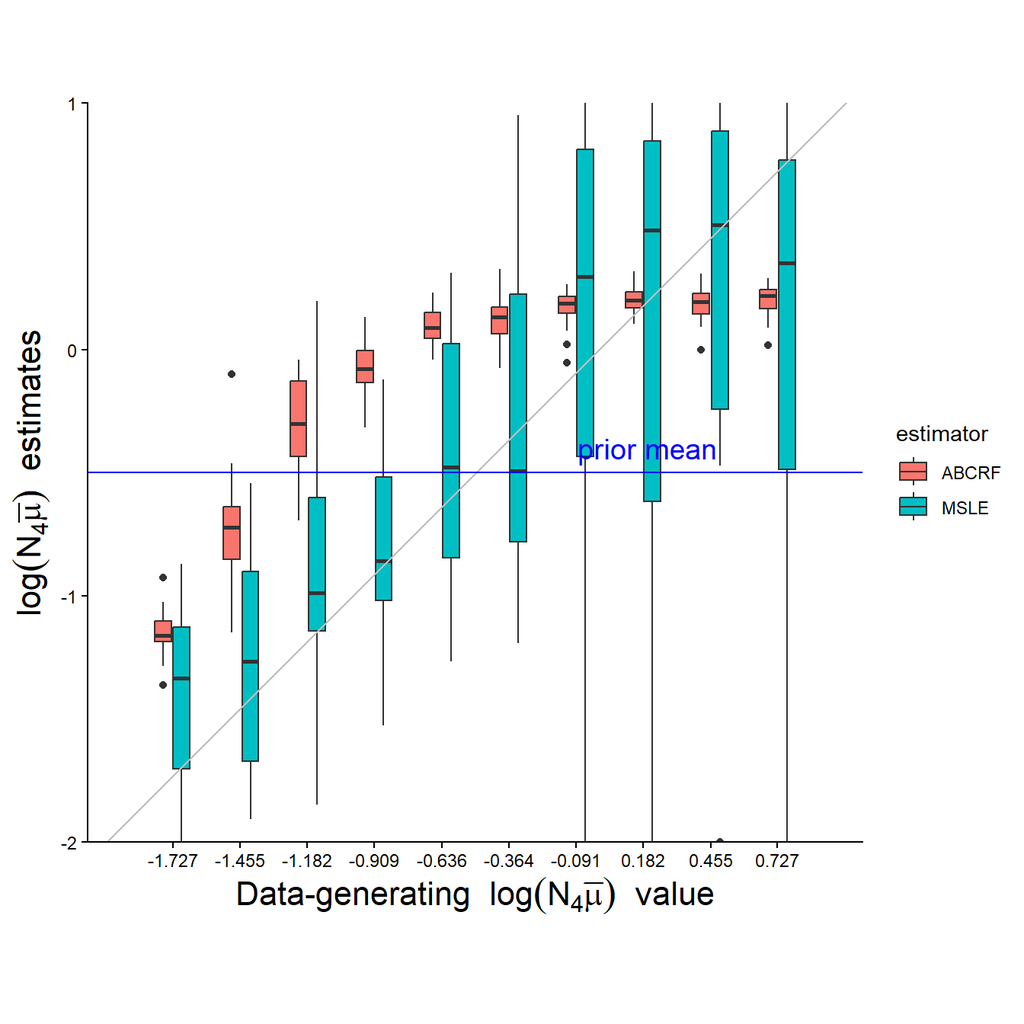

```r
# for (parm in names(LOWER)) {
  parm <- "logTh4"
  parmpm <- attr(TeX(par2ltx(parm)),"latex")
  xy_lims <- c(LOWER[parm],UPPER[parm])

  tib <- data.frame(ABCRF=df_extract(ecdfs_df,c("abcrf","logTh4","expectation"))[,1],
                    MSLE=df_extract(ecdfs_df,c("MSL","MSLE","logTh4")))
  tib <- tidyr::pivot_longer(tib,seq(ncol(tib)),names_to="estimator")
  tib$estimator <- factor(tib$estimator)
  unique_x <- unique(S_obs_table_info$par.grid[,parm])
  tib$DGP <- signif(unique_x,3)[gl(10,40)]

  # udf <- data.frame(ux=unique_x,uy=unique_x)

  xyplot <- ggplot(tib, aes(x=DGP, # continuous here
                            y=value,
                            group=interaction(DGP,estimator),
                            fill=estimator)
                  ) + geom_boxplot(width=0.15) + theme_classic() +
    coord_fixed() + # to control the proportions of the rendered plot
    labs(x=TeX(paste("Data-generating ",parmpm," value")) ,
         y=TeX(paste(parmpm," estimates"))) +
    theme(
      axis.title.y =  element_text(angle = 90,size=16),
      axis.title.x =  element_text(, size=16),
      axis.ticks.y = element_line(),
      axis.line.y = element_line(),
      axis.text.y = element_text()
    ) +
    scale_y_continuous(limits=c(-2,1), expand=expansion(add=c(0,0)) )  +
    scale_x_continuous(breaks=prettyround(unique_x,), expand=expansion(add=c(3/11,3/11))) +
    geom_abline(slope=1,intercept = 0,col="grey") +
    geom_hline(yintercept=-0.5, col="blue") +
    annotate("text", x = 0.2, y = -0.4, label = "prior mean", size=5, col="blue")

  print(xyplot)
```

```r
  ggsave(filename=paste0(MSdir,"boxp_",modelpath_nickname,".pdf"))
# }
```

# Human admixture scenario

## 7-parameter version with default controls

### Base simulations

```r
modelpath_nickname <- "N_7from17"
load4MS("diy2inf_simuls/admixtOutOfA/N_7from17/saves4Rmd.rda", verbose=TRUE)
```

```
## Loading objects:
##   LOWER
##   UPPER
##   scaDGparlist
```

```r
parms <- names(scaDGP <- unlist(scaDGparlist))
load4MS("diy2inf_simuls/admixtOutOfA/N_7from17/summaries_list.1_400.v2.1.196.3.rda") # first 200 from v2.187.1
lnames <- names(summaries_list)
(full_df_name <- paste0("df_",lnames[1],"_",tail(lnames,1)))
```

```
## [1] "df_1_400"
```

```r
assign(full_df_name, do.call(rbind, summaries_list))
ecdfs_df <- get(full_df_name)
perf_summs <- cp_perf_summs <- ad_hoc_fn(ecdfs_df, DGparlist = scaDGparlist, plot.=plot.)
```

#### Table

```r
{
  texcode <- lapply(perf_summs, vec2tex, retained=inmain,
                    bias_pos=bias_pos, RMSE_pos=RMSE_pos)
  texcode <- unlist(texcode)
  partexcode <- sapply(names(texcode), par2ltx )
  texcode <- paste(partexcode,"&", texcode)
  writeLines(texcode, con=paste0(MSdir,"table", modelpath_nickname,".ltx"))
}
{ # used later

  texcode <- lapply(perf_summs, vec2tex, retained=inms,
                    bias_pos=bias_pos, RMSE_pos=RMSE_pos)
  texcode <- unlist(texcode)
  partexcode <- sapply(names(texcode), par2ltx )
  texcode5K <- paste(" --- & 5000 &", texcode)
}
```

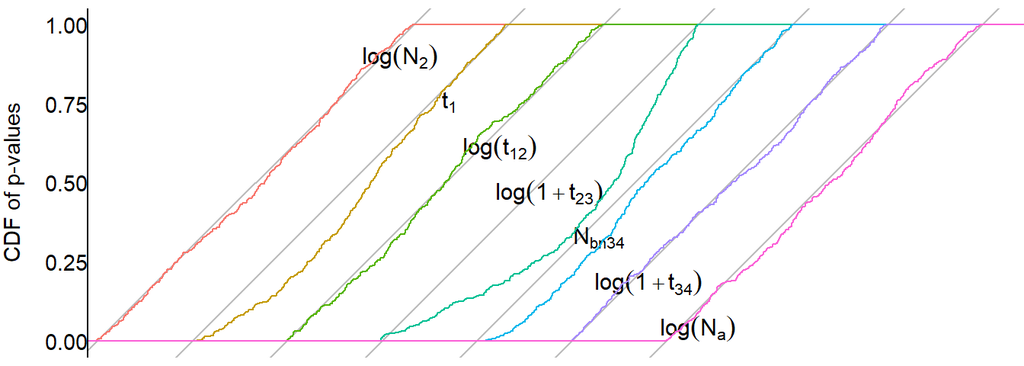

```r
myplot <- calc_ggplot(scaDGparlist, ecdfs_df, modelpath_nickname,
            which.p="basicLRT", xsep=0.3,
            filename=paste0(MSdir,"ecdfs_",modelpath_nickname,".pdf"))
print(myplot)
```

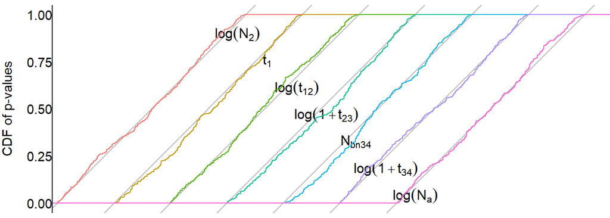

```r
myplot <- calc_ggplot(scaDGparlist, ecdfs_df, modelpath_nickname,
            which.p="rawBootLRT", xsep=0.3,
            filename=paste0(MSdir,"ecdfs_",modelpath_nickname,".rawboot.pdf"))
print(myplot)
```

### Larger datasets (10000 SNPs)

```r
which.p <- "basicLRT"
modelpath_nickname <- "Q_7from17"
load4MS("diy2inf_simuls/admixtOutOfA/Q_7from17/saves4Rmd.rda", verbose=TRUE)
```

```
## Loading objects:
##   LOWER
##   UPPER
##   scaDGparlist
```

```r
parms <- names(scaDGP <- unlist(scaDGparlist))
load4MS("diy2inf_simuls/admixtOutOfA/Q_7from17/summaries_list.1_200.v2.1.196.3.rda")
lnames <- names(summaries_list)
(full_df_name <- paste0("df_",lnames[1],"_",tail(lnames,1)))
```

```
## [1] "df_1_200"
```

```r
assign(full_df_name, do.call(rbind, summaries_list))
ecdfs_df <- get(full_df_name)
perf_summs <- ad_hoc_fn(ecdfs_df, DGparlist = scaDGparlist, plot.=plot.)
```

#### Table

```r
{
  texcode <- lapply(perf_summs, vec2tex, retained=inms,
                    bias_pos=bias_pos, RMSE_pos=RMSE_pos)
  texcode <- unlist(texcode)
  partexcode <- sapply(names(texcode), par2ltx )
  texcode <- texcode10K <- paste(partexcode,"& 10000 & ", texcode)
  writeLines(texcode, con=paste0(MSdir,"table", modelpath_nickname,".SI.ltx"))
  texcode5K10K <- c(texcode10K,texcode5K) # using textcode5K from a previous chunk
  texcode5K10K <- texcode5K10K[as.integer(gl(7,2))+c(0,7)]
  writeLines(texcode5K10K, con=paste0(MSdir,"table", paste0(modelpath_nickname,"vs5K"),".SI.ltx"))

}
```

```r
load4MS("diy2inf_simuls/admixtOutOfA/T_7from17_Nbn34_low/saves4Rmd.rda", verbose=TRUE)
```

```
## Loading objects:
##   LOWER
##   UPPER
##   scaDGparlist
```

```r
parms <- names(scaDGP <- unlist(scaDGparlist))
load4MS("diy2inf_simuls/admixtOutOfA/T_7from17_Nbn34_low/summaries_list.1_400.v2.2.20.rda")
lnames <- names(summaries_list)
(full_df_name <- paste0("df_",lnames[1],"_",tail(lnames,1)))
```

```
## [1] "df_1_400"
```

```r
assign(full_df_name, do.call(rbind, summaries_list))
ecdfs_df <- get(full_df_name)
perf_summs_low <- ad_hoc_fn(ecdfs_df, DGparlist = scaDGparlist, plot.=plot.)
#
load4MS("diy2inf_simuls/admixtOutOfA/S_7from17_Nbn34_hi/saves4Rmd.rda", verbose=TRUE)
```

```
## Loading objects:
##   LOWER
##   UPPER
##   scaDGparlist
```

```r
parms <- names(scaDGP <- unlist(scaDGparlist))
load4MS("diy2inf_simuls/admixtOutOfA/S_7from17_Nbn34_hi/summaries_list.1_400.v2.2.20.rda")
lnames <- names(summaries_list)
(full_df_name <- paste0("df_",lnames[1],"_",tail(lnames,1)))
```

```
## [1] "df_1_400"
```

```r
assign(full_df_name, do.call(rbind, summaries_list))
ecdfs_df <- get(full_df_name)
perf_summs_hi <- ad_hoc_fn(ecdfs_df, DGparlist = scaDGparlist, plot.=plot.)
#
```

#### Table

```r
{
  texcode <- lapply(perf_summs_low, vec2tex, retained=inms,
                    bias_pos=bias_pos, RMSE_pos=RMSE_pos)
  texcode <- unlist(texcode)
  partexcode <- sapply(names(texcode), par2ltx )
  texcode <- paste(partexcode,"&", texcode)
  writeLines(texcode, con=paste0(MSdir,"tableT_7from17_Nbn34_bnds_low.ltx"))
  #
  texcode <- lapply(perf_summs_hi, vec2tex, retained=inms,
                    bias_pos=bias_pos, RMSE_pos=RMSE_pos)
  texcode <- unlist(texcode)
  partexcode <- sapply(names(texcode), par2ltx )
  texcode <- paste(partexcode,"&", texcode)
  writeLines(texcode, con=paste0(MSdir,"tableS_7from17_Nbn34_bnds_hi.ltx"))
}
```

### Effect of iterative workflow on parameter exploration

```r
modelpath_nickname <- "N_7from17"
load4MS("diy2inf_simuls/admixtOutOfA/N_7from17/saves4Rmd.rda", verbose=TRUE)
# Next two files too big for inclusion in the SI repository
load("diy2inf_simuls/admixtOutOfA/N_7from17/saved_fits_2.1.187.1/upsliks_1.rda", verbose=TRUE)
load("diy2inf_simuls/admixtOutOfA/N_7from17/reftable_abcrf.rda")

slik <- upsliks$"20K"
pred_reft_slik <- predict(slik, newdata=slik$logLs[,names(LOWER)], which="safe")
pred_reft_abcrf <- predict(slik, newdata=reftable_abcrf_final[,names(LOWER)], which="safe")

focalpar <- "log1p.t23."
tib <- data.frame(par=c(reftable_abcrf_final[[focalpar]],
                        slik$logLs[[focalpar]]),
                  logl=c(pred_reft_abcrf, pred_reft_slik),
                  cut=cut(c(rep(0, 20000), slik$logLs$cumul_iter),
                          breaks = c(-0.5,0.5,10.5,Inf)))
xyplot <- ggplot(tib, aes(x=par, # continuous here
                          y=logl,
                          color=cut)) +
  geom_point(size=0.1) + theme_classic() +
  # coord_fixed() + # to control the proportions of the rendered plot
  labs(x=TeX(par2ltx(focalpar)) ,
       y="logL") +
  theme(
    legend.title=element_blank(),
    legend.position.inside = c(0.7, 0.2),
    axis.title.y =  element_text(angle = 90,size=16),
    axis.title.x =  element_text(, size=16),
    axis.ticks.y = element_line(),
    axis.line.y = element_line(),
    axis.text.y = element_text(),
    panel.border = element_rect(colour = "black", fill=NA, linewidth=1)
  ) + scale_color_manual(values=c('black','#E69F00', '#56B4E9'),
                         labels = c("ABCRF", "SL, iter 1-10","SL, iter > 10")) +
  guides(color = guide_legend(override.aes = list(size = 2),
                              position = "inside"))
# http://www.cookbook-r.com/Graphs/Colors_(ggplot2)/#a-colorblind-friendly-palette

print(xyplot)
ggsave(filename=paste0(MSdir,"logLexplo_t23.pdf"))

focalpar <- "Nbn34"
tib <- data.frame(par=c(reftable_abcrf_final[[focalpar]],
                        slik$logLs[[focalpar]]),
                  logl=c(pred_reft_abcrf, pred_reft_slik),
                  cut=cut(c(rep(0, 20000), slik$logLs$cumul_iter),
                          breaks = c(-0.5,0.5,10.5,Inf)))
xyplot <- ggplot(tib, aes(x=par, # continuous here
                          y=logl,
                          color=cut)) +
  geom_point(size=0.1) + theme_classic() +
  # coord_fixed() + # to control the proportions of the rendered plot
  labs(x=TeX(par2ltx(focalpar)) ,
       y="logL", color="") +
  theme(
    legend.title=element_blank(),
    legend.position.inside = c(0.7, 0.2),
    axis.title.y =  element_text(angle = 90,size=16),
    axis.title.x =  element_text(, size=16),
    axis.ticks.y = element_line(),
    axis.line.y = element_line(),
    axis.text.y = element_text(),
    panel.border = element_rect(colour = "black", fill=NA, linewidth=1)
  ) + scale_color_manual(values=c('black','#E69F00', '#56B4E9'),
                         labels = c("ABCRF", "SL, iter 1-10","ST, iter > 10")) +
  guides(color = guide_legend(override.aes = list(size = 2),
                              position = "inside"))

print(xyplot)
ggsave(filename=paste0(MSdir,"logLexplo_Nbn34.pdf"))
```

### Alternative sampling function

```r
modelpath_nickname <- "N_7from17"
load4MS("diy2inf_simuls/admixtOutOfA/N_7from17/saves4Rmd.rda", verbose=TRUE)
```

```
## Loading objects:
##   LOWER
##   UPPER
##   scaDGparlist
```

```r
parms <- names(scaDGP <- unlist(scaDGparlist))
# All inferences with v .203
load4MS("diy2inf_simuls/admixtOutOfA/N_7from17/summaries_list.altsampling.1_400.v2.1.203.rda")
lnames <- names(summaries_list)
(full_df_name <- paste0("df_",lnames[1],"_",tail(lnames,1)))
```

```
## [1] "df_1_400"
```

```r
assign(full_df_name, do.call(rbind, summaries_list))
ecdfs_df <- get(full_df_name)
perf_summs <- ad_hoc_fn(ecdfs_df, DGparlist = scaDGparlist, plot.=plot.)
{
  texcode <- lapply(perf_summs, vec2tex, retained=inmain,
                    bias_pos=NULL, RMSE_pos=NULL)
  texcode <- unlist(texcode)
  partexcode <- sapply(names(texcode), par2ltx )
  texcode <- paste(partexcode,"&", texcode)
  writeLines(texcode, con=paste0(MSdir,"table", modelpath_nickname,".altsampling.ltx"))
}
```

#### Comparisons on reference tables of 6000 samples

To perform these analyses, make a local modification of the `max_table_size` in the `generic_workflow.R` script.

```r
modelpath_nickname <- "N_7from17"
load4MS("diy2inf_simuls/admixtOutOfA/N_7from17/saves4Rmd.rda", verbose=TRUE)
```

```
## Loading objects:
##   LOWER
##   UPPER
##   scaDGparlist
```

```r
parms <- names(scaDGP <- unlist(scaDGparlist))
load4MS("diy2inf_simuls/admixtOutOfA/N_7from17/summaries_list.6K.1_400.v2.1.203.rda")
lnames <- names(summaries_list) # defective case
(full_df_name <- paste0("df_",lnames[1],"_",tail(lnames,1)))
```

```
## [1] "df_1_400"
```

```r
assign(full_df_name, do.call(rbind, summaries_list))
ecdfs_df <- get(full_df_name)
perf_summs <- ad_hoc_fn(ecdfs_df, DGparlist = scaDGparlist, plot.=FALSE)
texcodedef <- lapply(perf_summs, vec2tex, retained=c("bias.MSLE","RMSE.MSLE","cvrg.basicP"),
                    bias_pos=NULL, RMSE_pos=NULL)
texcodedef <- unlist(texcodedef)
#
load4MS("diy2inf_simuls/admixtOutOfA/altsampling/N_7from17/summaries_list.6K.1_400.v2.1.203.rda")
lnames <- names(summaries_list) # defective case
(full_df_name <- paste0("df_",lnames[1],"_",tail(lnames,1)))
```

```
## [1] "df_1_400"
```

```r
assign(full_df_name, do.call(rbind, summaries_list))
ecdfs_df <- get(full_df_name)
perf_summs_alt <- ad_hoc_fn(ecdfs_df, DGparlist = scaDGparlist, plot.=FALSE)
texcodealt <- lapply(perf_summs_alt, vec2tex, retained=c("bias.MSLE","RMSE.MSLE","cvrg.basicP"),
                    bias_pos=NULL, RMSE_pos=NULL)
texcodealt <- unlist(texcodealt)
texcode <- paste(gsub("\\\\ ", "& ",texcodedef, fixed=TRUE),texcodealt)
partexcode <- sapply(names(texcodedef), par2ltx )
texcode <- paste(partexcode,"&", texcode)
writeLines(texcode, con=paste0(MSdir,"table", modelpath_nickname,".samplings6K.ltx"))
```

### Synthetic reference table

```r
modelpath_nickname <- "N_7from17"
load4MS("diy2inf_simuls/admixtOutOfA/N_7from17/saves4Rmd.rda", verbose=TRUE)
```

```
## Loading objects:
##   LOWER
##   UPPER
##   scaDGparlist
```

```r
parms <- names(scaDGP <- unlist(scaDGparlist))
load4MS("diy2inf_simuls/admixtOutOfA/N_7from17/synthetic/summaries_list.1_200.v2.1.196.3.rda")
lnames <- names(summaries_list)
(full_df_name <- paste0("df_",lnames[1],"_",tail(lnames,1)))
```

```
## [1] "df_1_200"
```

```r
assign(full_df_name, do.call(rbind, summaries_list))
ecdfs_df <- get(full_df_name)
perf_summs <- ad_hoc_fn(ecdfs_df, DGparlist = scaDGparlist, plot.=plot.)
```

#### Table

```r
{
  texcode <- lapply(perf_summs, vec2tex, retained=inmain,
                    bias_pos=NULL, RMSE_pos=NULL)
  texcode <- unlist(texcode)
  partexcode <- sapply(names(texcode), par2ltx )
  texcode <- paste(partexcode,"&", texcode)
  writeLines(texcode, con=paste0(MSdir,"table", modelpath_nickname,".synthetic.200.ltx"))
}
```

#### Figure ECDFs

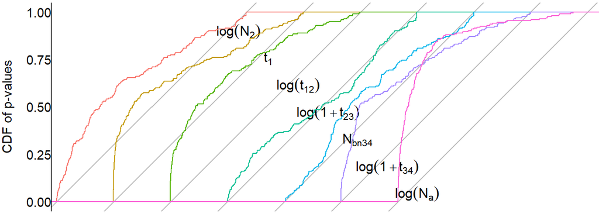

```r
myplot <- calc_ggplot(scaDGparlist, ecdfs_df, modelpath_nickname,
            which.p="basicLRT", xsep=0.3,
            filename=paste0(MSdir,"ecdfs_",modelpath_nickname,".synthetic.200.pdf"))
print(myplot)
```

### Inference by SNLE using `sbi` python package

The following chunk of code makes sure that all files is included:

```r
save4MS("diy2inf_simuls/admixtOutOfA/N_7from17/SNLE/summarize_snle.R")
filenames <- c("diyabc-RF-linux-v1.1.36-o", "headerRF.txt", "human.snp", "human.snpbin.txt",
               "maf.txt",  "S_obs_table.txt", "RNG_state_0000.bin",
               "snle_N_7from17.py", "statobs.txt","statobsRF.txt"  )
for (nam in filenames) save4MS(paste0("diy2inf_simuls/admixtOutOfA/N_7from17/SNLE/allfilesforeachjob/", nam))
```

```r
modelpath_nickname <- "N_7from17"
load4MS("diy2inf_simuls/admixtOutOfA/N_7from17/saves4Rmd.rda", verbose=TRUE)
```

```
## Loading objects:
##   LOWER
##   UPPER
##   scaDGparlist
```

```r
parms <- names(scaDGP <- unlist(scaDGparlist))
load4MS("diy2inf_simuls/admixtOutOfA/N_7from17/SNLE/SNLE_summaries.rda", verbose=TRUE) # postm, q1s,s2s
```

```
## Loading objects:
##   postm
##   q1s
##   q2s
```

```r
summs <- vector("list", 7L)
names(summs) <- parms
for (parm in parms) {
  m <- (postm[,parm] - scaDGP[parm])/(UPPER[parm] - LOWER[parm])
  cover <- (q1s[,parm]< scaDGP[parm] & q2s[,parm] > scaDGP[parm] )
  summs[[parm]] <- c(cp_perf_summs[[parm]][c("bias.MSLE","RMSE.MSLE","cvrg.mslCI","cvrg.rawbootP","cvrg.bartlettP")],
                     c(bias.SNLE=mean(m),
                          RMSE.SNLE=sqrt(mean(m^2)),
                          cvrg.SNLE=sum(cover)/length(cover))
  )
}

texcode <- lapply(
  summs, vec2tex,
  retained=names(summs[[1]]),
  bias_pos=c(1,6), RMSE_pos=c(2,7), # cvrg_pos=c(3,6),
  loc_ord_names=names(summs[[1]]))
texcode <- unlist(texcode)
partexcode <- sapply(names(texcode), par2ltx )
texcode <- paste(partexcode,"&", texcode)
writeLines(texcode, con=paste0(MSdir,"table", modelpath_nickname,"SNLE.ltx"))
```

## 13-parameter version

### With composite bottleneck parameters

```r
modelpath_nickname <- "O_13from17"
load4MS("diy2inf_simuls/admixtOutOfA/O_13from17/saves4Rmd.rda", verbose=TRUE)
```

```
## Loading objects:
##   LOWER
##   UPPER
##   scaDGparlist
```

```r
parms <- names(scaDGP <- unlist(scaDGparlist))
load4MS("diy2inf_simuls/admixtOutOfA/O_13from17/summaries_list.1_400.v2.1.196.3-203.rda")
lnames <- names(summaries_list)
(full_df_name <- paste0("df_",lnames[1],"_",tail(lnames,1)))
```

```
## [1] "df_1_400"
```

```r
assign(full_df_name, do.call(rbind, summaries_list))
ecdfs_df <- get(full_df_name)
#perf_summs <- ad_hoc_fn(ecdfs_df[-c(1,100,34,13),], DGparlist = scaDGparlist, plot.=plot.)
perf_summs <- perf_summs_38K <- ad_hoc_fn(ecdfs_df, DGparlist = scaDGparlist, plot.=plot.)
sub_perf_summs_38K <- ad_hoc_fn(ecdfs_df[1:200,], DGparlist = scaDGparlist, plot.=plot.)
```

#### Table default controls

```r
{
  texcode <- lapply(perf_summs, vec2tex, retained=inmain,
                    bias_pos=bias_pos, RMSE_pos=RMSE_pos)
  texcode <- unlist(texcode)
  partexcode <- sapply(names(texcode), par2ltx )
  texcode <- paste(partexcode,"&", texcode)
  writeLines(texcode, con=paste0(MSdir,"table", modelpath_nickname,".ltx"))
}
```

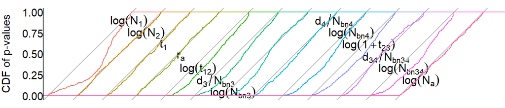

```r
myplot <- calc_ggplot(scaDGparlist, ecdfs_df, modelpath_nickname,
            which.p="basicLRT", xsep=0.35,
            filename=paste0(MSdir,"ecdfs_",modelpath_nickname,".pdf"))
print(myplot)
```

#### With larger reference table

```r
modelpath_nickname <- "O_13from17"
load4MS("diy2inf_simuls/admixtOutOfA/O_13from17/saves4Rmd.rda", verbose=TRUE)
```

```
## Loading objects:
##   LOWER
##   UPPER
##   scaDGparlist
```

```r
parms <- names(scaDGP <- unlist(scaDGparlist))
load4MS("diy2inf_simuls/admixtOutOfA/O_13from17/summaries_list.50K.1_200.v2.1.203.rda")
lnames <- names(summaries_list)
(full_df_name <- paste0("df_",lnames[1],"_",tail(lnames,1)))
```

```
## [1] "df_1_200"
```

```r
assign(full_df_name, do.call(rbind, summaries_list))
ecdfs_df <- get(full_df_name)
#perf_summs <- ad_hoc_fn(ecdfs_df[-c(1,100,34,13),], DGparlist = scaDGparlist, plot.=plot.)
perf_summs <- perf_summs_50K <- ad_hoc_fn(ecdfs_df, DGparlist = scaDGparlist, plot.=plot.)
```

##### Table

```r
{
  texcode <- lapply(perf_summs, vec2tex, retained=inms,
                    bias_pos=NULL, RMSE_pos=NULL)
  texcode <- unlist(texcode)
  partexcode <- sapply(names(texcode), par2ltx )
  texcode <- paste(partexcode,"&", texcode)
  writeLines(texcode, con=paste0(MSdir,"table", modelpath_nickname,".50K.SI.ltx"))
}
```

#### Check ABC-RF inference of $\log(N_1)$

```r
  load4MS("diy2inf_simuls/admixtOutOfA/O_13from17_logN1/S_obs_table.rda", verbose=TRUE) # for S_obs_table_info
```

```
## Loading objects:
##   S_obs_table
##   S_obs_table_info
```

```r
  load4MS("diy2inf_simuls/admixtOutOfA/O_13from17_logN1/summaries_list.rda")
  lnames <- names(summaries_list)
  (full_df_name <- paste0("df_",lnames[1],"_",tail(lnames,1)))
```

```
## [1] "df__"
```

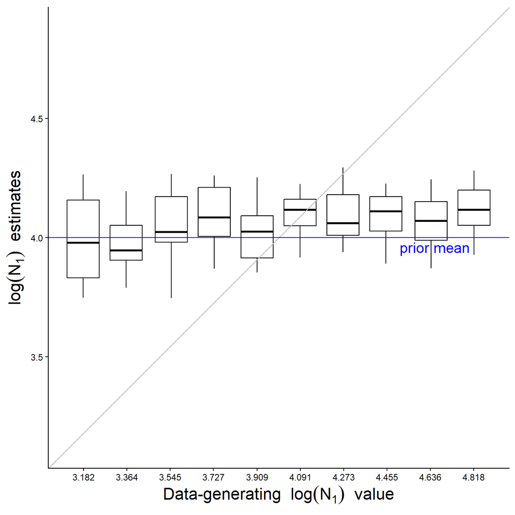

```r
  assign(full_df_name, do.call(rbind, summaries_list))
  ecdfs_df <- get(full_df_name)

  focalpar <- "log.N1."
  parmpm <- attr(TeX(par2ltx(focalpar)),"latex")
  xy_lims <- c(LOWER[focalpar],UPPER[focalpar])

  tib <- data.frame(ABCRF=df_extract(ecdfs_df,c("abcrf",focalpar,"expectation"))[,1])
  tib <- tidyr::pivot_longer(tib,seq(1),names_to="estimator")
  tib$estimator <- factor(tib$estimator)
  unique_x <- unique(S_obs_table_info$par.grid[,focalpar])
  tib$DGP <- signif(unique_x,3)[gl(10,20)]

  udf <- data.frame(ux=unique_x,uy=unique_x)

  xrange <- range(c(unique_x))
  xrange <- xrange + (xrange[2]-xrange[1])*c(-1,1)/11

xyplot <- ggplot(tib, aes(x=DGP, # continuous here
                          y=value,
                          group=DGP,
                          col=estimator)
) + geom_boxplot(show.legend = FALSE, color="black") +  theme_classic() +
  coord_fixed() + # to control the proportions of the rendered plot
  labs(x=TeX(paste("Data-generating ",parmpm," value")) ,
       y=TeX(paste(parmpm," estimates"))) +
  theme(
    axis.title.y =  element_text(angle = 90,size=16),
    axis.title.x =  element_text(, size=16),
    axis.ticks.y = element_line(),
    axis.line.y = element_line(),
    axis.text.y = element_text()
  ) +
  scale_x_continuous(limits=xrange, breaks=prettyround(unique_x,-1), expand=expansion(add=c(0,0))) +
  scale_y_continuous(limits=range(c(xrange, tib$value)), expand=expansion(add=c(0,0)) )  +
  geom_abline(slope=1,intercept = 0,col="grey") +
  geom_hline(yintercept=(LOWER+UPPER)[focalpar]/2, col="blue") +
  annotate("text", x = (0.1*min(unique_x)+0.9*max(unique_x)),
                   y = (LOWER+UPPER)[focalpar]/2-0.02*(UPPER-LOWER)[focalpar],
           label = "prior mean", size=5, col="blue")


print(xyplot)
```

```r
ggsave(filename=paste0(MSdir,"boxp_","O_13from17_logN1",".pdf"))
```

Summary-likelihood inferences were not run on these datasets.

#### Check ABC-RF inference of `log.Nbn34.`

```r
  load4MS("diy2inf_simuls/admixtOutOfA/O_13from17_logNbn34/S_obs_table.rda", verbose=TRUE) # for S_obs_table_info
```

```
## Loading objects:
##   S_obs_table
##   S_obs_table_info
```

```r
  load4MS("diy2inf_simuls/admixtOutOfA/O_13from17_logNbn34/summaries_list.rda")
  lnames <- names(summaries_list)
  (full_df_name <- paste0("df_",lnames[1],"_",tail(lnames,1)))
```

```
## [1] "df__"
```

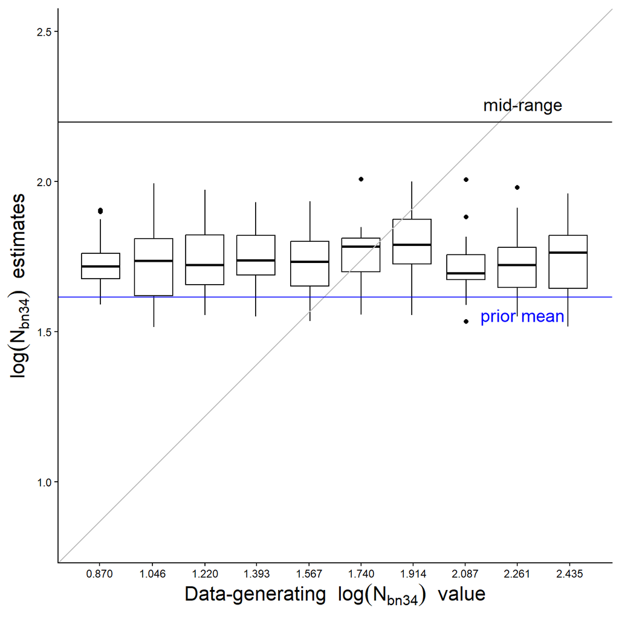

```r
  assign(full_df_name, do.call(rbind, summaries_list))
  ecdfs_df <- get(full_df_name)

  focalpar <- "log.Nbn34."
  parmpm <- attr(TeX(par2ltx(focalpar)),"latex")
  xy_lims <- c(LOWER[focalpar],UPPER[focalpar])

  tib <- data.frame(ABCRF=df_extract(ecdfs_df,c("abcrf",focalpar,"expectation"))[,1])
  tib <- tidyr::pivot_longer(tib,seq(1),names_to="estimator")
  tib$estimator <- factor(tib$estimator)
  unique_x <- unique(S_obs_table_info$par.grid[,focalpar])
  tib$DGP <- signif(unique_x,3)[gl(10,20)]

  udf <- data.frame(ux=unique_x,uy=unique_x)

  xrange <- range(c(unique_x))
  xrange <- xrange + (xrange[2]-xrange[1])*c(-1,1)/11

xyplot <- ggplot(tib, aes(x=DGP, # continuous here
                          y=value,
                          group=DGP,
                          col=estimator)
) + geom_boxplot(show.legend = FALSE, color="black") +  theme_classic() +
  coord_fixed() + # to control the proportions of the rendered plot
  labs(x=TeX(paste("Data-generating ",parmpm," value")) ,
       y=TeX(paste(parmpm," estimates"))) +
  theme(
    axis.title.y =  element_text(angle = 90,size=16),
    axis.title.x =  element_text(, size=16),
    axis.ticks.y = element_line(),
    axis.line.y = element_line(),
    axis.text.y = element_text()
  ) +
  scale_x_continuous(limits=xrange, breaks=prettyround(unique_x,-1), expand=expansion(add=c(0,0))) +
  scale_y_continuous(limits=range(c(xrange, tib$value)), expand=expansion(add=c(0,0)) )  +
  geom_abline(slope=1,intercept = 0,col="grey") +
  geom_hline(yintercept=(LOWER+UPPER)[focalpar]/2, col="black") +
  annotate("text", x = (0.1*min(unique_x)+0.9*max(unique_x)),
                   y = (LOWER+UPPER)[focalpar]/2+0.02*(UPPER-LOWER)[focalpar],
           label = "mid-range", size=5, col="black")+
  geom_hline(yintercept=1.6150559, col="blue") +
  annotate("text", x = (0.1*min(unique_x)+0.9*max(unique_x)),
                   y = 1.6150559-0.02*(UPPER-LOWER)[focalpar], # from the reftable_abcrf
           label = "prior mean", size=5, col="blue")

print(xyplot)
```

```r
ggsave(filename=paste0(MSdir,"boxp_","O_13from17_logNbn34",".pdf"))
```

#### Real-data inferences

Production of SI table from saved `abcrf` and `Infusion` inference results:

```r
load4MS("diy2inf_simuls/admixtOutOfA/O_13from17/actual_data_inferences.summaries.rda")

confints <- lapply(summ_inference_maxK[["CIs"]], function(v) v[[1]]$interval)
post_quantiles <- lapply(abcrf_resu, function(v) v$quantiles)
HPDints <- lapply(abcrf_resu, function(v) v$HPDint_d)
texcode <- sapply(names(confints), function(v)
  paste(par2ltx(v), "&",
        signif(summ_inference_maxK$MSL$MSLE[[v]], 3),"&",
        signif(abcrf_resu[[v]]$"expectation", 3),"&",
        signif(abcrf_resu[[v]]$"med", 3),"&",
        paste(signif(confints[[v]],3), collapse="--"),"&",
    paste(signif(HPDints[[v]],3), collapse="--"),"&",
    paste(signif(post_quantiles[[v]],3), collapse="--")," \\\\ "
  )
)

(texcode <- unlist(texcode))

writeLines(texcode, con=paste0(MSdir,"table.fit_real_O13from17.ltx"))
```

### Diagnosing the distribution of LRTs for $d_3/N_{\textrm{bn3}}$

#### Base simulations for 4-parameter sub-model

```r
modelpath_nickname <- "P_4from17"
load4MS("diy2inf_simuls/admixtOutOfA/P_4from17/saves4Rmd.rda", verbose=TRUE)
```

```
## Loading objects:
##   LOWER
##   UPPER
##   scaDGparlist
```

```r
load4MS("diy2inf_simuls/admixtOutOfA/P_4from17/summaries_list.1_500.v2.1.196.3.rda")
lnames <- names(summaries_list)
(full_df_name <- paste0("df_",lnames[1],"_",tail(lnames,1)))
```

```
## [1] "df_1_500"
```

```r
assign(full_df_name, do.call(rbind, summaries_list))
ecdfs_df <- get(full_df_name)
perf_summs <- ad_hoc_fn(ecdfs_df, DGparlist = scaDGparlist, plot.=plot.)
```

```
## NA/NaN in LRT_rstar for log.t12. for replicate(s) 4,7,15,20,24,51,54,59,69,77,90,115,128,165,205,206,283,294,296,300,343,390,446.
```

```
## NA/NaN in LRT_rstar for d3_Nbn3 for replicate(s) 4,15,20,29,36,51,55,59,61,70,73,107,137,140,144,165,169,174,176,199,225,238,264,281,293,296,316,328,344,351,365,369,377,403,445,450,466,471,484,492,499.
```

```
## NA/NaN in LRT_rstar for log.Nbn3. for replicate(s) 4,15,20,29,36,45,49,51,59,61,69,77,113,128,136,137,140,165,178,199,203,217,238,240,293,296,313,316,324,328,329,344,351,365,367,377,382,403,412,429,450,466,471,492.
```

```
## NA/NaN in LRT_rstar for log.Na. for replicate(s) 61,90,109,189,204,231,269,343,344,349,351,360,417,458,492.
```

##### Table

```r
{
  texcode <- lapply(perf_summs, vec2tex, retained=inms[c(1,4,7,8,9)],
                    bias_pos=NULL, RMSE_pos=NULL)
  texcode <- unlist(texcode)
  partexcode <- sapply(names(texcode), par2ltx )
  texcode <- paste(partexcode,"&", texcode)
  writeLines(texcode, con=paste0(MSdir,"table", modelpath_nickname,".adhoc.SI.ltx"))
}
```

##### Figure ECDFs for for `d3/Nbn3` in 4-parameter sub-model

(This generates warnings)

```r
 # special version for diagnosing d3_Nbn3 LRTs:
# This requires canonize() so reloading all defs for P_4from17
    focalpar <- "d3_Nbn3"
    # Extract solution vectors:
    profsols <- df_extract(ecdfs_df,c("SLRTs",focalpar), finalFUN=function(v) attr(v$chi2_LR,"solution"))
    # Colors: implied d3 from tested h0s$d3_Nbn3 and d3_Nbn3-profile value of Nbn3:
    prof_d3s <- apply(profsols, 1L, function(v) {scaDGparlist$d3_Nbn3* 10^v["log.Nbn3."]})
    d3_cuts <- cut(prof_d3s,breaks = c(-Inf,0.5,1.5,2.5,5.5,10.5,20.5,Inf))
    MLE_d3s <- apply(df_extract(ecdfs_df,c("MSL","MSLE")),1,
                     function(v) {v["d3_Nbn3"]*10^v["log.Nbn3."]})
    high_MLE_d3s <- (MLE_d3s>32.73206)
    sum(high_MLE_d3s) # 189 over 500
```

```
## [1] 189
```

```r
    LRp <- df_extract(ecdfs_df,c("SLRTs",focalpar,"basicLRT"))$p_value
    lo_LRp <- LRp[ ! high_MLE_d3s]
    hi_LRp <- c(LRp[high_MLE_d3s], rep(NA, 122))
    bootp <- df_extract(ecdfs_df,c("SLRTs",focalpar,"rawBootLRT"))$p_value
    lo_bootp <- bootp[ ! high_MLE_d3s]
    hi_bootp <- c(bootp[high_MLE_d3s], rep(NA, 122))
    tib <- cbind(lo_LRp=lo_LRp, hi_LRp=hi_LRp, lo_bootp=lo_bootp, hi_bootp=hi_bootp)
  nr <- nrow(tib)
  steps <- 5L
  npar <- 4L
  xsep <- 0.3
  ysep <- 1/steps
  ann_size <- 4
  tib  <- as.data.frame(tib+(as.numeric(gl(npar+1L,nr))-1)[-(623:933)]*xsep)
  tib   <- tidyr::pivot_longer(tib,seq(npar),names_to="parameter")
  tib$parameter <- factor(tib$parameter)

  texlabels <- c("low","high","low","high")

  dev.new(width=10, height=2.5)

  xfix <- c(1,2,4,5) # for ablines

  myplot <- ggplot(tib, aes(value, col=parameter))
  for (jt in seq(4)) {
    it <- c(1,2,4,5)[jt]
    kt <- c(1L,2L,1L,2L)[jt]
    xshift <- c(0,0,1.5,1.5)[jt]
    idx <- (jt-1) %% 2L

    xy   <- c( x = 0.9+(idx)*(xsep-ysep)+xshift*2L*xsep,
               y = 0.9-(idx)*ysep)
    myplot <- myplot +
      geom_abline(slope=1,intercept=-(it-1)*xsep, col="grey") +
      annotate("text", x = xy["x"], y = xy["y"],
               label = texlabels[[jt]], size=ann_size)
  }

   myplot <- myplot + annotate("text", x = 1, y = 1.1,
               label = "LRT", size=ann_size) + annotate("text", x = 2, y = 1.1,
               label = "bootstrap", size=ann_size)

  myplot <- myplot + stat_ecdf(geom="step") + theme_void() +
    coord_fixed() +
    labs(y="CDF of p-values\n") +
    theme(
      axis.title.y =  element_text(angle = 90),
      axis.ticks.y = element_line(),
      axis.line.y = element_line(),
      axis.text.y = element_text(),
      legend.position="none"
    ) +
    # scale_color_discrete(labels=texlabels) +
    scale_y_continuous(breaks=seq(0,1,0.25)) +
    scale_x_continuous(expand=expansion(mult=c(0.05,0.05)))

  ggsave(filename=paste0(MSdir,"ecdfs_d3_Nbn3_P_4from17.pdf"))
  print(myplot)
```

[output not shown]

#### 2D profile

This was produced from the second of the 200 simulated datasets for the 13-parameter case with composite parameters, refitted in a 4-parameter sub-model. The likelihood surface is here inferred using a reference table of 22000 samples. The horizontal ridge near `log.Nbn3.`=0.7 happens for $d_3=2$ and $N_{\textrm{bn3}}=5$ as `log.Nbn3.` and `d3_Nbn3` are drawn as continuous variables but the simulation software rounds times and population sizes to integer values. The intermediate reference table of 11000 samples already provided the same pattern. The following code was first used to produce the figure

```r
# Next file too big for inclusion in Supplementary Information repository
load(file="diy2inf_simuls/admixtOutOfA/P_4from17/saved_info_for_2Dprofile/slik.22K.rda")
# Slow!:
Infusion::plot2Dprof(slik22, list("d3_Nbn3","log.Nbn3."), gridSteps = 65L,
                  color.palette=function(n){
                    adjustcolor(Infusion:::.viridisOpts(option="H", n, begin=0.1))
                    }
                  )
```

but the long part of the computation was saved so that the Figure can be reproduced by

```r
load4MS(file="diy2inf_simuls/admixtOutOfA/P_4from17/saved_info_for_2Dprofile/profiles_info.rda")
pdf(paste0(MSdir, "2Dprofile_b3_P4from17.22K.pdf"),width = 5,height = 6.5) # dim not controlled by the chunk args args...
Infusion::plot2Dprof(profiles_info$fit_info,
           pars=list("d3_Nbn3","log.Nbn3."),
           profiles = profiles_info$profiles,
           color.palette = function(n) grDevices::hcl.colors(n=n ,palette="viridis", rev=TRUE),
           xylabs=c(d3_Nbn3=latex2exp::TeX("$b_3=d_3/N_{\\textrm{bn3}}$"),
                    log.Nbn3.=latex2exp::TeX(par2ltx("log.Nbn3."))))
```

```r
dev.off()
```

### Without composite bottleneck parameters

```r
modelpath_nickname <- "B_13from17"
load4MS("diy2inf_simuls/admixtOutOfA/B_13from17/saves4Rmd.rda", verbose=TRUE)
```

```
## Loading objects:
##   LOWER
##   UPPER
##   scaDGparlist
```

```r
parms <- names(scaDGP <- unlist(scaDGparlist))
load4MS("diy2inf_simuls/admixtOutOfA/B_13from17/summaries_list.1_200.v2.1.196.3.rda") # fits v2.1.187.1
lnames <- names(summaries_list)
(full_df_name <- paste0("df_",lnames[1],"_",tail(lnames,1)))
```

```
## [1] "df_1_200"
```

```r
assign(full_df_name, do.call(rbind, summaries_list))
ecdfs_df <- get(full_df_name)
perf_summs <- ad_hoc_fn(ecdfs_df, DGparlist = scaDGparlist, plot.=plot.)
```

#### Table

```r
{
  texcode <- lapply(perf_summs, vec2tex, retained=inms,
                    bias_pos=bias_pos, RMSE_pos=RMSE_pos)
  texcode <- unlist(texcode)
  partexcode <- sapply(names(texcode), par2ltx )
  texcode <- paste(partexcode,"&", texcode)
  writeLines(texcode, con=paste0(MSdir,"table", modelpath_nickname,".SI.ltx"))
}
```

#### Figure ECDFs

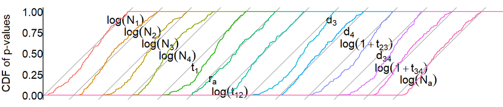

```r
myplot <- calc_ggplot(scaDGparlist, ecdfs_df, modelpath_nickname,
            which.p="basicLRT", xsep=0.35,
            filename=paste0(MSdir,"ecdfs_",modelpath_nickname,".pdf"))
print(myplot)
```

# Toy example: multivariate Normal distribution

## Fully identifiable model

### Summary-likelihood inferences

```r
modelpath_nickname <- "MVNcovmat"
load4MS("toyTests/MVNcovmat/saves4Rmd.rda", verbose=TRUE)
```

```
## Loading objects:
##   LOWER
##   UPPER
##   cholDGPv
```

```r
scaDGparlist <- as.list(cholDGPv)
load4MS("toyTests/MVNcovmat/summaries_list.1_400.v2.1.203.rda") # with bootstraps
lnames <- names(summaries_list)
(full_df_name <- paste0("df_",lnames[1],"_",tail(lnames,1)))
```

```
## [1] "df_1_400"
```

```r
assign(full_df_name, do.call(rbind, summaries_list))
ecdfs_df <- get(full_df_name)
```

```r
  perf_summs <- perf_summs_TFI <- ad_hoc_fn(ecdfs_df, DGparlist = scaDGparlist, plot.=plot.)
  texcode <- lapply(perf_summs, vec2tex, retained=inmain,
                    bias_pos=NULL, RMSE_pos=NULL)
  texcode <- unlist(texcode)
  partexcode <- sapply(names(texcode), par2ltx )
  texcode <- paste(partexcode,"&", texcode)
  writeLines(texcode, con=paste0(MSdir,"table", modelpath_nickname,".ltx"))
  cvrg.bootCI.TFI <- do.call(rbind, perf_summs)[,"cvrg.bartlettP"]
```

### Inference by SNLE using `sbi` python package

The following chunk of code makes sure that the given files are included in the published code:

```r
save4MS("toyTests/MVNcovmat/SNLE/S_obs_table.txt") # simulated data (from R)
save4MS("toyTests/MVNcovmat/SNLE/snle_MVNcovmat.py") # python script to run inferences
# script to assemble SNLE_summaries.rda from the raw Python files:
save4MS("toyTests/MVNcovmat/SNLE/summarize_snle.R")
```

```r
load4MS("toyTests/MVNcovmat/saves4Rmd.rda", verbose=TRUE) # LOWER, UPPER, cholDGPv
```

```
## Loading objects:
##   LOWER
##   UPPER
##   cholDGPv
```

```r
load4MS("toyTests/MVNcovmat/SNLE/SNLE_summaries.rda", verbose=TRUE) # postm, q1s,s2s
```

```
## Loading objects:
##   postm
##   q1s
##   q2s
```

```r
modelpath_nickname <- "MVNcovmat"

summs <- vector("list", 15L)
names(summs) <- Rord_names <- names(LOWER)
for (parm in names(summs)) {
  m <- (postm[,parm] - cholDGPv[parm])/(UPPER[parm] - LOWER[parm])
  cover <- (q1s[,parm]< cholDGPv[parm] & q2s[,parm] > cholDGPv[parm] )
  summs[[parm]] <- c(perf_summs_TFI[[parm]][c("bias.MSLE","RMSE.MSLE","cvrg.mslCI","cvrg.rawbootP","cvrg.bartlettP")],
                     c(bias.SNLE=mean(m),
                          RMSE.SNLE=sqrt(mean(m^2)),
                          cvrg.SNLE=sum(cover)/length(cover))
  )
}

texcode <- lapply(
  summs, vec2tex,
  retained=names(summs[[1]]),
  bias_pos=c(1,6), RMSE_pos=c(2,7), # cvrg_pos=c(3,6),
  loc_ord_names=names(summs[[1]]))
texcode <- unlist(texcode)
partexcode <- sapply(names(texcode), par2ltx )
texcode <- paste(partexcode,"&", texcode)
writeLines(texcode, con=paste0(MSdir,"table", modelpath_nickname,"SNLE.ltx"))


# Graphical comparison of interval widths
SLCIwidths <- numeric(15)
names(SLCIwidths) <- Rord_names
for (st in names(SLCIwidths)) {
  interv <- df_extract(ecdfs_df,c("CIs",st,"0.95","interval"))
  print(c(sum(is.na(interv[,1])),sum(is.na(interv[,2])))) # some intervals reach the bounds
  interv[is.na(interv[,1]),1] <-  LOWER[st]
  interv[is.na(interv[,2]),2] <-  UPPER[st]
  SLCIwidths[st] <- mean(interv[,2]-interv[,1])
}
```

```
## [1] 0 0
## [1] 12  0
## [1] 0 0
## [1] 0 0
## [1] 0 0
## [1] 0 0
## [1] 0 2
## [1] 3 0
## [1] 0 0
## [1] 0 0
## [1]  0 87
## [1] 0 0
## [1] 0 0
## [1] 0 0
## [1] 0 0
```

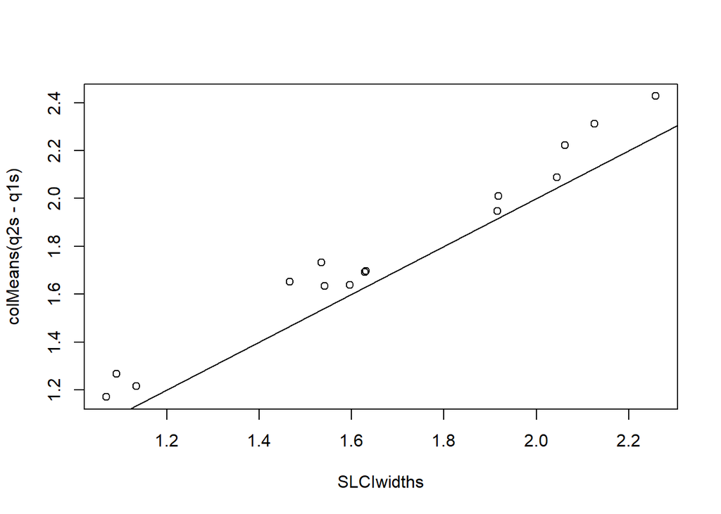

```r
plot(SLCIwidths, colMeans(q2s-q1s))
abline(0,1)
```

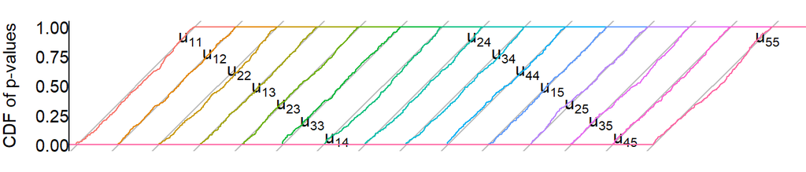

```r
myplot <- calc_ggplot(scaDGparlist, ecdfs_df, modelpath_nickname,
            which.p="basicLRT", xsep=0.35,
            filename=paste0(MSdir,"ecdfs_",modelpath_nickname,".pdf")
            )
print(myplot)
```

## Non-identifiable parameters

```r
modelpath_nickname <- "MVNcovmat_identif"
load4MS("toyTests/MVNcovmat_identif/saves4Rmd.rda", verbose=TRUE)
```

```
## Loading objects:
##   LOWER
##   UPPER
##   cholDGPv
```

```r
scaDGparlist <- as.list(cholDGPv)
load4MS("toyTests/MVNcovmat_identif/summaries_list.1_400.v2.1.203.rda")
lnames <- names(summaries_list)
(full_df_name <- paste0("df_",lnames[1],"_",tail(lnames,1)))
```

```
## [1] "df_1_400"
```

```r
assign(full_df_name, do.call(rbind, summaries_list))
ecdfs_df <- get(full_df_name)
### was needed for summaries_list with non-standard format:
#ori <- ecdfs_df
#foo <- lapply(seq(200), function(it) list(MSL=list(MSLE=ori[it,"MSLE"][[1]],
#                                                   hessian=NA), SLRTs=ori[it,"SLRTs"][[1]]))
#ecdfs_df <- do.call(rbind,foo)
```

```r
  perf_summs <- perf_summs_NI <- ad_hoc_fn(ecdfs_df, DGparlist = scaDGparlist, plot.=plot.)
  texcode <- lapply(perf_summs, vec2tex, retained=inmain,
                    bias_pos=NULL, RMSE_pos=NULL)
  texcode <- unlist(texcode)
  partexcode <- sapply(names(texcode), par2ltx )
  texcode <- paste(partexcode,"&", texcode)
  writeLines(texcode[c(1,3,6,10,15)], con=paste0(MSdir,"table",modelpath_nickname,".ltx"))
  cvrg.bootCI.NI <- do.call(rbind, perf_summs)[,"cvrg.bartlettP"]
```

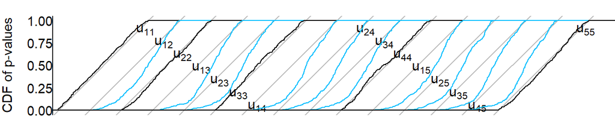

```r
loccol <- rep("#00BFFF",15)
loccol[c(1,3,6,10,15)] <- "black"

myplot <- calc_ggplot(scaDGparlist, ecdfs_df, modelpath_nickname,
            which.p="basicLRT", xsep=0.35, scale_col=loccol,
            filename=paste0(MSdir,"ecdfs_",modelpath_nickname,".pdf"))
print(myplot)
```

## Test of clustering controls

### Power rule $n^{0.31}$ versus alternatives

```r
modelpath_nickname <- "MVNpow"
load4MS("toyTests/MVN6/saves4Rmd.rda", verbose=TRUE)
```

```
## Loading objects:
##   LOWER
##   UPPER
##   cholDGPv
```

```r
scaDGparlist <- as.list(cholDGPv)
load4MS("toyTests/MVN6/pow31/summaries_list.1_1000.v2.2.20.rda") # without bootstraps
lnames <- names(summaries_list)
(full_df_name <- paste0("df_",lnames[1],"_",tail(lnames,1)))
```

```
## [1] "df_1_1000"
```

```r
assign(full_df_name, do.call(rbind, summaries_list))
ecdfs_df_pow31 <- get(full_df_name)
#
load4MS("toyTests/MVN6/pow33/summaries_list.1_1000.v2.2.20.rda") # without bootstraps
lnames <- names(summaries_list)
(full_df_name <- paste0("df_",lnames[1],"_",tail(lnames,1)))
```

```
## [1] "df_1_1000"
```

```r
assign(full_df_name, do.call(rbind, summaries_list))
ecdfs_df_pow33 <- get(full_df_name)
#
load4MS("toyTests/MVN6/pow29/summaries_list.1_1000.v2.2.20.rda") # without bootstraps
lnames <- names(summaries_list)
(full_df_name <- paste0("df_",lnames[1],"_",tail(lnames,1)))
```

```
## [1] "df_1_1000"
```

```r
assign(full_df_name, do.call(rbind, summaries_list))
ecdfs_df_pow29 <- get(full_df_name)
```

```r
  perf_summs_pow31 <- ad_hoc_fn(ecdfs_df_pow31, DGparlist = scaDGparlist, plot.=plot.)
  perf_summs_pow33 <- ad_hoc_fn(ecdfs_df_pow33, DGparlist = scaDGparlist, plot.=plot.)
  perf_summs_pow29 <- ad_hoc_fn(ecdfs_df_pow29, DGparlist = scaDGparlist, plot.=plot.)
  perf_summs <- perf_summs_pow29

  retained <- c("bias.MSLE","RMSE.MSLE","cvrg.mslCI",
                "bias.MSLE ","RMSE.MSLE ","cvrg.mslCI ",
                "bias.MSLE  ","RMSE.MSLE  ","cvrg.mslCI  ") # The spaces in the names matter!
  for (it in seq(6)) {
    perf_summs[[it]] <- c(perf_summs_pow29[[it]][c("bias.MSLE","RMSE.MSLE","cvrg.mslCI")],
                          perf_summs_pow31[[it]][c("bias.MSLE","RMSE.MSLE","cvrg.mslCI")],
                          perf_summs_pow33[[it]][c("bias.MSLE","RMSE.MSLE","cvrg.mslCI")])
    names(perf_summs[[it]]) <- retained
  }
  texcode <- lapply(perf_summs, vec2tex, retained=retained, loc_ord_names=retained,
                    bias_pos=c(1,4,7), RMSE_pos=c(2,5,8), cvrg_pos=c(3,6,9))
  texcode <- unlist(texcode)
  partexcode <- sapply(names(texcode), par2ltx )
  texcode <- paste(partexcode,"&", texcode)
  writeLines(texcode, con=paste0(MSdir,"table",modelpath_nickname,".ltx"))
```

### $P\leq n/4$ rule versus alternatives

```r
modelpath_nickname <- "MVNnr3nr8"
load4MS("toyTests/MVNcovmat/saves4Rmd.rda", verbose=TRUE)
```

```
## Loading objects:
##   LOWER
##   UPPER
##   cholDGPv
```

```r
scaDGparlist <- as.list(cholDGPv)
load4MS("toyTests/nr8/MVNcovmat/summaries_list.1_400.v2.2.20.rda") # without bootstraps
lnames <- names(summaries_list)
(full_df_name <- paste0("df_",lnames[1],"_",tail(lnames,1)))
```

```
## [1] "df_1_400"
```

```r
assign(full_df_name, do.call(rbind, summaries_list))
ecdfs_df_nr8 <- get(full_df_name)
load4MS("toyTests/nr3/MVNcovmat/summaries_list.1_200.v2.2.20.rda") # with bootstraps
lnames <- names(summaries_list)
(full_df_name <- paste0("df_",lnames[1],"_",tail(lnames,1)))
```

```
## [1] "df_1_200"
```

```r
assign(full_df_name, do.call(rbind, summaries_list))
ecdfs_df_nr3a <- get(full_df_name)
# remove bootstraps
for (it in seq(200)) {
  for (jt in seq(15)) {
  ecdfs_df_nr3a[it,"CIs"][[1]][[jt]][["0.95"]]  <-
    ecdfs_df_nr3a[it,"CIs"][[1]][[jt]][["0.95"]][c("lowerpar","upperpar","interval")]
  }
}
load4MS("toyTests/nr3/MVNcovmat/summaries_list.201_400.v2.2.20.rda") # without bootstraps
lnames <- names(summaries_list)
(full_df_name <- paste0("df_",lnames[1],"_",tail(lnames,1)))
```

```
## [1] "df_201_400"
```

```r
assign(full_df_name, do.call(rbind, summaries_list))
ecdfs_df_nr3b <- get(full_df_name)
ecdfs_df_nr3 <- rbind(ecdfs_df_nr3a,ecdfs_df_nr3b)
```

```r
  perf_summs_nr8 <- ad_hoc_fn(ecdfs_df_nr8, DGparlist = scaDGparlist, plot.=plot.)
  perf_summs_nr3 <- ad_hoc_fn(ecdfs_df_nr3, DGparlist = scaDGparlist, plot.=plot.)
  perf_summs <- perf_summs_nr3
  retained <- c("bias.MSLE","RMSE.MSLE","cvrg.mslCI",
                                 "bias.MSLE ","RMSE.MSLE ","cvrg.mslCI ")
  for (it in seq(15)) {
    perf_summs[[it]] <- c(perf_summs_nr3[[it]][c("bias.MSLE","RMSE.MSLE","cvrg.mslCI")],
                          perf_summs_nr8[[it]][c("bias.MSLE","RMSE.MSLE","cvrg.mslCI")])
    names(perf_summs[[it]]) <- retained
  }
  texcode <- lapply(perf_summs, vec2tex, retained=retained, loc_ord_names=retained,
                    bias_pos=c(1,4), RMSE_pos=c(2,5), cvrg_pos=c(3,6))
  texcode <- unlist(texcode)
  partexcode <- sapply(names(texcode), par2ltx )
  texcode <- paste(partexcode,"&", texcode)
  writeLines(texcode, con=paste0(MSdir,"table",modelpath_nickname,".ltx"))
```